# Mini curso - Introducção a computacao bayesiana

2025-10-28

## Stan

Há diferentes interfaces para Stan, incluindo CmdStanR (interface com R), CmdStanPy (interface com Python), além de interfaces com Matlab, Julia e Mathematica.

Detalhes sobre instalação: https://mc-stan.org

### Estrutura básica de um código **Stan**

A estrutura mais simples de um código **Stan** é composta por **três blocos**:  
**data**, **parameters** e **model**, conforme mostrado abaixo:

```stan
data {
   declaração dos dados Y
}
parameters {
   declaração dos parâmetros θ a serem amostrados
}
model {
   descrição das verossimilhanças p(Y|θ)
   descrição das distribuições a priori p(θ)
}
```

### Simple Linear Regression

X: anos de experiência Y: salário anual

```r
#setwd("~/Documents/GitHub/Mini-curso_CompBayes/Data")
setwd("~/Library/Mobile Documents/com~apple~CloudDocs/Documents/GitHub/Mini-curso_CompBayes/Data")
salary = read.csv("data-salary.csv")
head(salary)
```

```
##    X    Y
## 1  7 45.7
## 2 10 48.2
## 3 16 51.8
## 4 25 53.5
## 5  5 42.7
## 6 25 60.3
```

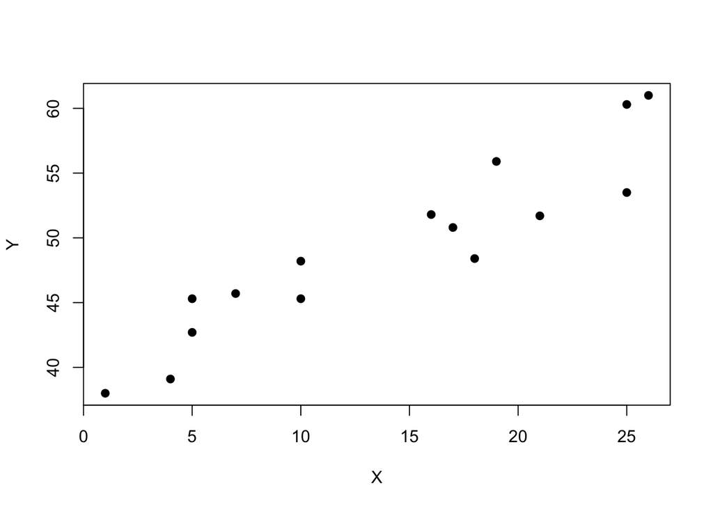

```r
plot(salary, pch = 19)
```

```r
library(cmdstanr)
model_lin <- "
data {
  int<lower=0> N;
  vector[N] X;
  vector[N] Y;
}
parameters {
  real alpha;
  real beta;
  real<lower=0> sigma;
}
model {
  Y ~ normal(alpha + beta * X, sigma);
}
"

data <- list(N=nrow(salary), X=salary$X, Y=salary$Y)
model <- cmdstan_model(write_stan_file(model_lin))
#model <- cmdstan_model(stan_file='model_lin.stan')
fit <- model$sample(data=data, seed=123, chains = 1,iter_warmup = 1000, iter_sampling = 1000)
```

```
## Running MCMC with 1 chain...
##
## Chain 1 Iteration:    1 / 2000 [  0%]  (Warmup)
## Chain 1 Iteration:  100 / 2000 [  5%]  (Warmup)
## Chain 1 Iteration:  200 / 2000 [ 10%]  (Warmup)
## Chain 1 Iteration:  300 / 2000 [ 15%]  (Warmup)
## Chain 1 Iteration:  400 / 2000 [ 20%]  (Warmup)
## Chain 1 Iteration:  500 / 2000 [ 25%]  (Warmup)
## Chain 1 Iteration:  600 / 2000 [ 30%]  (Warmup)
## Chain 1 Iteration:  700 / 2000 [ 35%]  (Warmup)
## Chain 1 Iteration:  800 / 2000 [ 40%]  (Warmup)
## Chain 1 Iteration:  900 / 2000 [ 45%]  (Warmup)
## Chain 1 Iteration: 1000 / 2000 [ 50%]  (Warmup)
## Chain 1 Iteration: 1001 / 2000 [ 50%]  (Sampling)
## Chain 1 Iteration: 1100 / 2000 [ 55%]  (Sampling)
## Chain 1 Iteration: 1200 / 2000 [ 60%]  (Sampling)
## Chain 1 Iteration: 1300 / 2000 [ 65%]  (Sampling)
## Chain 1 Iteration: 1400 / 2000 [ 70%]  (Sampling)
## Chain 1 Iteration: 1500 / 2000 [ 75%]  (Sampling)
## Chain 1 Iteration: 1600 / 2000 [ 80%]  (Sampling)
## Chain 1 Iteration: 1700 / 2000 [ 85%]  (Sampling)
## Chain 1 Iteration: 1800 / 2000 [ 90%]  (Sampling)
## Chain 1 Iteration: 1900 / 2000 [ 95%]  (Sampling)
## Chain 1 Iteration: 2000 / 2000 [100%]  (Sampling)
## Chain 1 finished in 0.1 seconds.
```

```r
library(bayesplot)
library(posterior)
fit$summary()
```

```
## # A tibble: 4 × 10
##   variable    mean  median     sd    mad      q5     q95  rhat ess_bulk ess_tail
##   <chr>      <dbl>   <dbl>  <dbl>  <dbl>   <dbl>   <dbl> <dbl>    <dbl>    <dbl>
## 1 lp__     -21.6   -21.2   1.43   1.07   -24.2   -20.2   1.000     375.     534.
## 2 alpha     38.7    38.8   1.44   1.42    36.2    41.0   1.00      325.     432.
## 3 beta       0.751   0.748 0.0912 0.0883   0.609   0.910 1.00      303.     426.
## 4 sigma      2.93    2.80  0.703  0.574    2.04    4.12  0.999     412.     475.
```

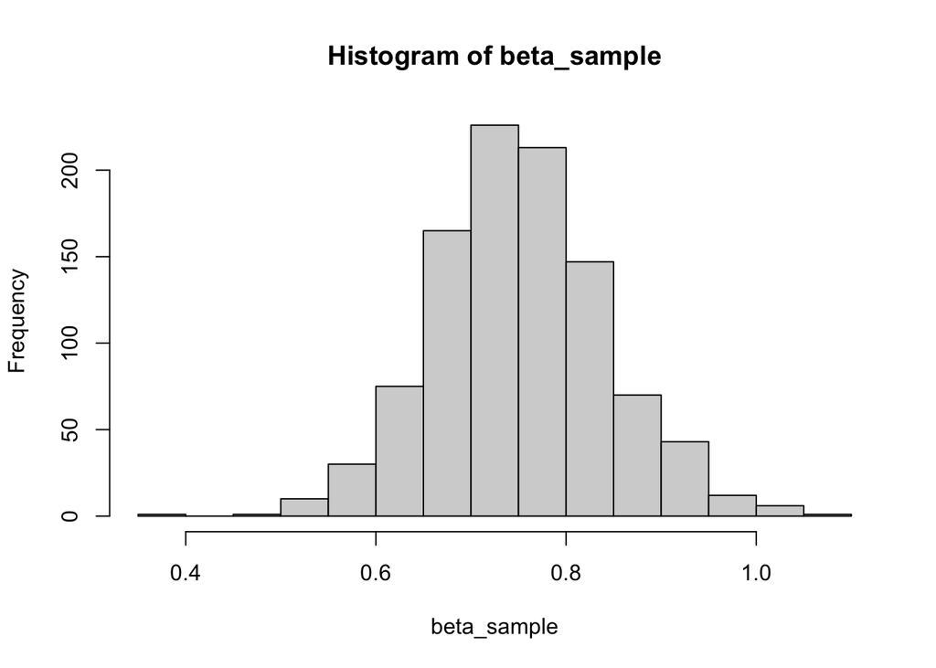

```r
beta_sample <- as_draws_matrix(fit$draws("beta"))
hist(beta_sample)
```

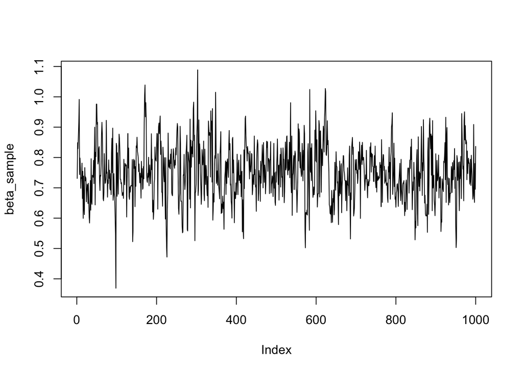

```r
plot(beta_sample,type="l")
```

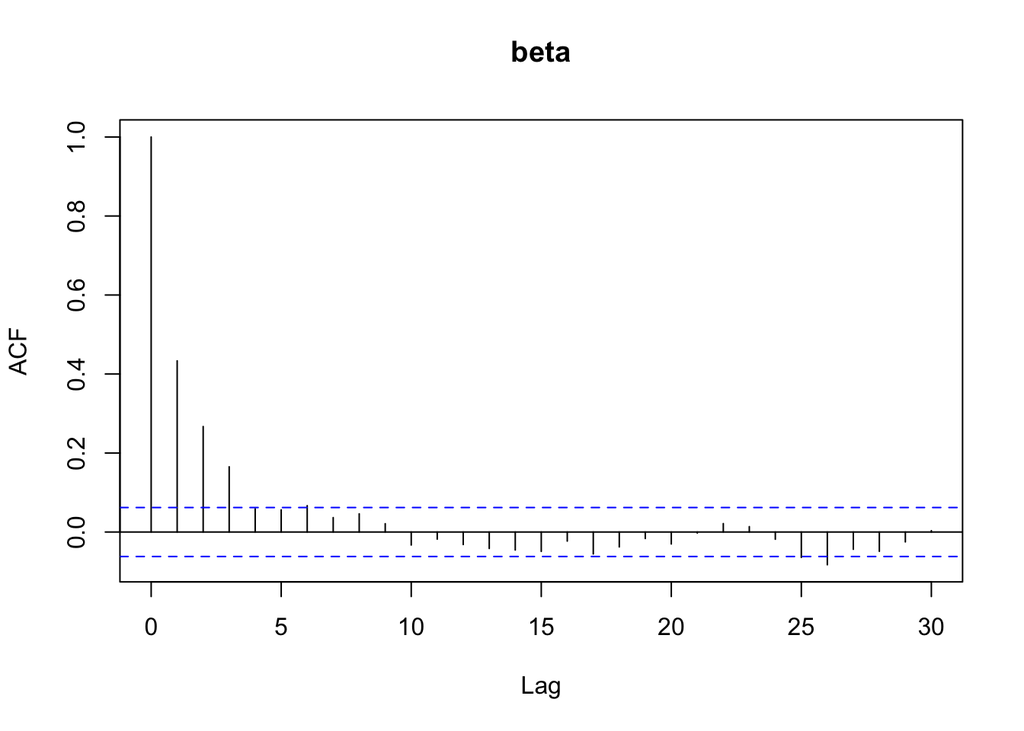

```r
acf(beta_sample)
```

### Predições

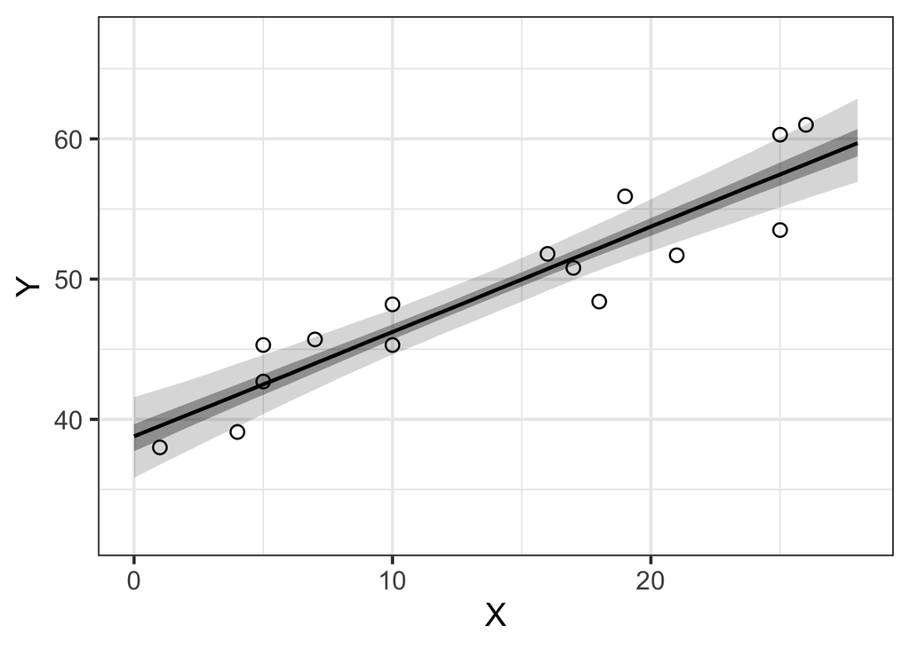

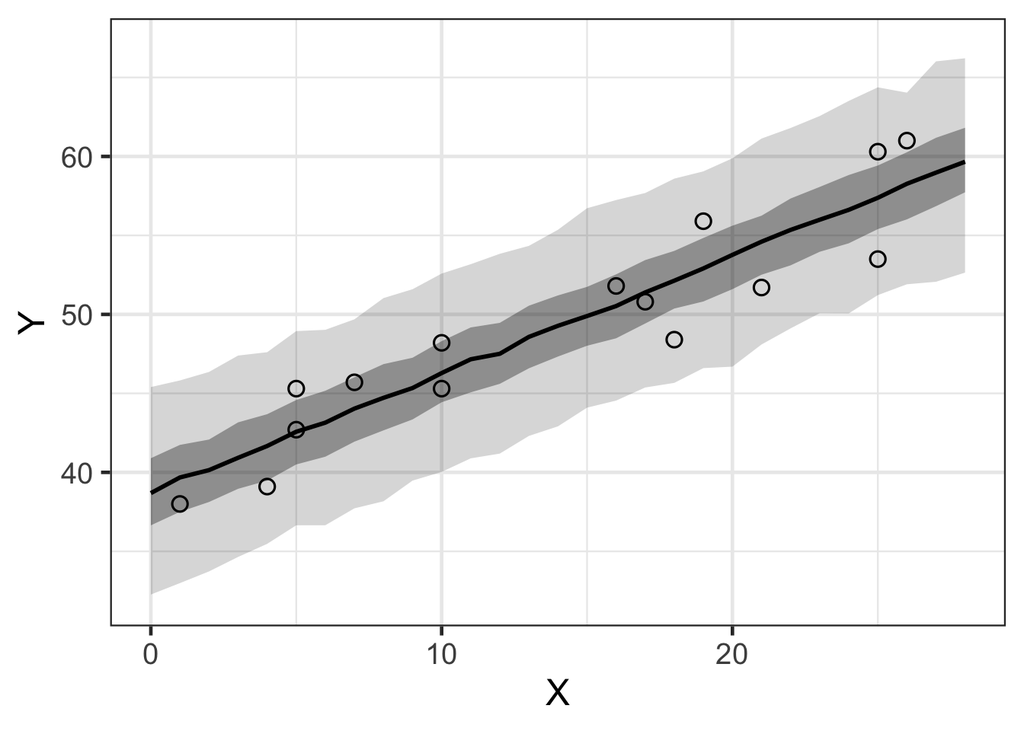

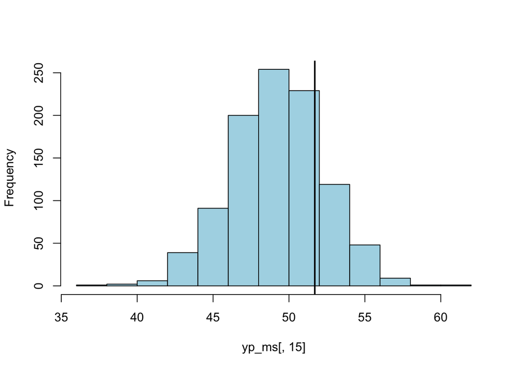

```r
hist(yp_ms[,15], col = "lightblue",main = "")
abline(v = salary$Y[15], lwd = 2)
```

### Regressão Logística

Outras distribuições de referência: https://mc-stan.org/docs/2_18/functions-reference/conventions-for-probability-functions.html

```r
model_reg_logistica <- "
data {
  int<lower=0> N;         // número de observações
  int<lower = 0> p;
  matrix[N,p] X;            // preditor
  array[N] int<lower=0, upper=1> y;  // resposta binária (0 ou 1)
}

parameters {
  vector[p] beta;              // coeficiente do preditor
}

model {
  // Priors

  beta ~ normal(0, 10);

  // Likelihood
  y ~ bernoulli_logit(X * beta);

  // ou
  //p = inv_logit(alpha + X * beta);  // converte logit -> probabilidade
  //y ~ bernoulli(p);                 // Bernoulli com p
}
generated quantities {
  vector[N] log_lik;
  for (i in 1:N)
    log_lik[i] = bernoulli_logit_lpmf(y[i] | X[i] * beta);
}
"
```

Vamos usar o low birth weight data data.frame que contém com 189 linhas e 11 variáveis:

- **id**: Código de identificação
- **low**: Baixo peso ao nascer (1: ≥ 2500 g, 2: < 2500 g)
- **age**: Idade da mãe (em anos)
- **lwt**: Peso da mãe no último período menstrual (em libras)
- **race**: Raça (1: Branca, 2: Negra, 3: Outra)
- **smoke**: Tabagismo durante a gravidez (0: Não, 1: Sim)
- **ptl**: Histórico de parto prematuro (1: Nenhum, : Um, 3: Dois, etc.)
- **ht**: Histórico de hipertensão (1: Não, 2: Sim)
- **ui**: Presença de irritabilidade uterina (1: Não, 2: Sim)
- **ftv**: Número de consultas médicas no primeiro trimestre (1: Nenhuma, 2: Uma, 3: Duas, etc.)
- **bwt**: Peso do bebê ao nascer (em gramas)

```r
library(aplore3)
lowbwt = aplore3::lowbwt
head(lowbwt)
```

```
##   id      low age lwt  race smoke  ptl  ht  ui       ftv  bwt
## 1  4 < 2500 g  28 120 Other   Yes  One  No Yes      None  709
## 2 10 < 2500 g  29 130 White    No None  No Yes Two, etc. 1021
## 3 11 < 2500 g  34 187 Black   Yes None Yes  No      None 1135
## 4 13 < 2500 g  25 105 Other    No  One Yes  No      None 1330
## 5 15 < 2500 g  25  85 Other    No None  No Yes      None 1474
## 6 16 < 2500 g  27 150 Other    No None  No  No      None 1588
```

```r
lowbwt$y = ifelse(lowbwt$low == "< 2500 g", 1, 0)
X = model.matrix(~ age + lwt + race + smoke +ht +ui + ftv, data = lowbwt)

dat = list(N = dim(lowbwt)[1], X = X, y = lowbwt$y,p =ncol(X))
model <- cmdstan_model(write_stan_file(model_reg_logistica))

fit <- model$sample(data=dat, seed=123, chains = 1, parallel_chains = 1, iter_warmup = 1000,iter_sampling = 3000,
                    thin = 1, save_warmup = FALSE)
```

```
## Running MCMC with 1 chain...
##
## Chain 1 Iteration:    1 / 4000 [  0%]  (Warmup)
## Chain 1 Iteration:  100 / 4000 [  2%]  (Warmup)
## Chain 1 Iteration:  200 / 4000 [  5%]  (Warmup)
## Chain 1 Iteration:  300 / 4000 [  7%]  (Warmup)
## Chain 1 Iteration:  400 / 4000 [ 10%]  (Warmup)
## Chain 1 Iteration:  500 / 4000 [ 12%]  (Warmup)
## Chain 1 Iteration:  600 / 4000 [ 15%]  (Warmup)
## Chain 1 Iteration:  700 / 4000 [ 17%]  (Warmup)
## Chain 1 Iteration:  800 / 4000 [ 20%]  (Warmup)
## Chain 1 Iteration:  900 / 4000 [ 22%]  (Warmup)
## Chain 1 Iteration: 1000 / 4000 [ 25%]  (Warmup)
## Chain 1 Iteration: 1001 / 4000 [ 25%]  (Sampling)
## Chain 1 Iteration: 1100 / 4000 [ 27%]  (Sampling)
## Chain 1 Iteration: 1200 / 4000 [ 30%]  (Sampling)
## Chain 1 Iteration: 1300 / 4000 [ 32%]  (Sampling)
## Chain 1 Iteration: 1400 / 4000 [ 35%]  (Sampling)
## Chain 1 Iteration: 1500 / 4000 [ 37%]  (Sampling)
## Chain 1 Iteration: 1600 / 4000 [ 40%]  (Sampling)
## Chain 1 Iteration: 1700 / 4000 [ 42%]  (Sampling)
## Chain 1 Iteration: 1800 / 4000 [ 45%]  (Sampling)
## Chain 1 Iteration: 1900 / 4000 [ 47%]  (Sampling)
## Chain 1 Iteration: 2000 / 4000 [ 50%]  (Sampling)
## Chain 1 Iteration: 2100 / 4000 [ 52%]  (Sampling)
## Chain 1 Iteration: 2200 / 4000 [ 55%]  (Sampling)
## Chain 1 Iteration: 2300 / 4000 [ 57%]  (Sampling)
## Chain 1 Iteration: 2400 / 4000 [ 60%]  (Sampling)
## Chain 1 Iteration: 2500 / 4000 [ 62%]  (Sampling)
## Chain 1 Iteration: 2600 / 4000 [ 65%]  (Sampling)
## Chain 1 Iteration: 2700 / 4000 [ 67%]  (Sampling)
## Chain 1 Iteration: 2800 / 4000 [ 70%]  (Sampling)
## Chain 1 Iteration: 2900 / 4000 [ 72%]  (Sampling)
## Chain 1 Iteration: 3000 / 4000 [ 75%]  (Sampling)
## Chain 1 Iteration: 3100 / 4000 [ 77%]  (Sampling)
## Chain 1 Iteration: 3200 / 4000 [ 80%]  (Sampling)
## Chain 1 Iteration: 3300 / 4000 [ 82%]  (Sampling)
## Chain 1 Iteration: 3400 / 4000 [ 85%]  (Sampling)
## Chain 1 Iteration: 3500 / 4000 [ 87%]  (Sampling)
## Chain 1 Iteration: 3600 / 4000 [ 90%]  (Sampling)
## Chain 1 Iteration: 3700 / 4000 [ 92%]  (Sampling)
## Chain 1 Iteration: 3800 / 4000 [ 95%]  (Sampling)
## Chain 1 Iteration: 3900 / 4000 [ 97%]  (Sampling)
## Chain 1 Iteration: 4000 / 4000 [100%]  (Sampling)
## Chain 1 finished in 1.8 seconds.
```

```r
print(fit)
```

```
##  variable    mean  median   sd  mad      q5     q95 rhat ess_bulk ess_tail
##   lp__    -107.02 -106.64 2.40 2.16 -111.48 -103.87 1.00     1171     1556
##   beta[1]    0.60    0.60 1.23 1.26   -1.42    2.59 1.00     1517     1934
##   beta[2]   -0.02   -0.02 0.04 0.04   -0.08    0.04 1.00     1894     1904
##   beta[3]   -0.02   -0.02 0.01 0.01   -0.03   -0.01 1.00     2007     2271
##   beta[4]    1.34    1.34 0.55 0.53    0.43    2.25 1.00     2136     1959
##   beta[5]    0.93    0.92 0.45 0.45    0.20    1.68 1.00     1636     1894
##   beta[6]    1.06    1.05 0.41 0.40    0.39    1.73 1.00     1709     1735
##   beta[7]    2.04    2.02 0.74 0.72    0.83    3.33 1.00     2607     1674
##   beta[8]    0.93    0.94 0.46 0.46    0.16    1.68 1.00     3516     2176
##   beta[9]   -0.21   -0.19 0.47 0.46   -1.00    0.54 1.00     2336     2117
##
##  # showing 10 of 200 rows (change via 'max_rows' argument or 'cmdstanr_max_rows' option)
```

```r
library(coda)
posterior_mat <- as_draws_matrix(fit$draws("beta"))
HPDinterval(as.mcmc(posterior_mat), prob = 0.95)
```

```
##                lower       upper
## beta[1]  -1.77197610  2.93176460
## beta[2]  -0.08927164  0.05624723
## beta[3]  -0.03278889 -0.00424280
## beta[4]   0.21941892  2.38723750
## beta[5]   0.06768435  1.81491910
## beta[6]   0.23381386  1.84417100
## beta[7]   0.56135348  3.51119560
## beta[8]   0.07520989  1.85956480
## beta[9]  -1.06372430  0.78521024
## beta[10] -0.78875939  1.02841990
## attr(,"Probability")
## [1] 0.95
```

```r
lowbwt$y = ifelse(lowbwt$low == "< 2500 g", 1, 0)
X = model.matrix(~ age + lwt + race + smoke +ht +ui + ftv, data = lowbwt)

dat = list(N = dim(lowbwt)[1], X = X, y = lowbwt$y,p =ncol(X))
model <- cmdstan_model(write_stan_file(model_reg_logistica))

fit2 <- model$sample(data=dat, seed=123, chains = 1, parallel_chains = 1, iter_warmup = 1000,iter_sampling = 3000,
                    thin = 1, save_warmup = FALSE)
```

```
## Running MCMC with 1 chain...
##
## Chain 1 Iteration:    1 / 4000 [  0%]  (Warmup)
## Chain 1 Iteration:  100 / 4000 [  2%]  (Warmup)
## Chain 1 Iteration:  200 / 4000 [  5%]  (Warmup)
## Chain 1 Iteration:  300 / 4000 [  7%]  (Warmup)
## Chain 1 Iteration:  400 / 4000 [ 10%]  (Warmup)
## Chain 1 Iteration:  500 / 4000 [ 12%]  (Warmup)
## Chain 1 Iteration:  600 / 4000 [ 15%]  (Warmup)
## Chain 1 Iteration:  700 / 4000 [ 17%]  (Warmup)
## Chain 1 Iteration:  800 / 4000 [ 20%]  (Warmup)
## Chain 1 Iteration:  900 / 4000 [ 22%]  (Warmup)
## Chain 1 Iteration: 1000 / 4000 [ 25%]  (Warmup)
## Chain 1 Iteration: 1001 / 4000 [ 25%]  (Sampling)
## Chain 1 Iteration: 1100 / 4000 [ 27%]  (Sampling)
## Chain 1 Iteration: 1200 / 4000 [ 30%]  (Sampling)
## Chain 1 Iteration: 1300 / 4000 [ 32%]  (Sampling)
## Chain 1 Iteration: 1400 / 4000 [ 35%]  (Sampling)
## Chain 1 Iteration: 1500 / 4000 [ 37%]  (Sampling)
## Chain 1 Iteration: 1600 / 4000 [ 40%]  (Sampling)
## Chain 1 Iteration: 1700 / 4000 [ 42%]  (Sampling)
## Chain 1 Iteration: 1800 / 4000 [ 45%]  (Sampling)
## Chain 1 Iteration: 1900 / 4000 [ 47%]  (Sampling)
## Chain 1 Iteration: 2000 / 4000 [ 50%]  (Sampling)
## Chain 1 Iteration: 2100 / 4000 [ 52%]  (Sampling)
## Chain 1 Iteration: 2200 / 4000 [ 55%]  (Sampling)
## Chain 1 Iteration: 2300 / 4000 [ 57%]  (Sampling)
## Chain 1 Iteration: 2400 / 4000 [ 60%]  (Sampling)
## Chain 1 Iteration: 2500 / 4000 [ 62%]  (Sampling)
## Chain 1 Iteration: 2600 / 4000 [ 65%]  (Sampling)
## Chain 1 Iteration: 2700 / 4000 [ 67%]  (Sampling)
## Chain 1 Iteration: 2800 / 4000 [ 70%]  (Sampling)
## Chain 1 Iteration: 2900 / 4000 [ 72%]  (Sampling)
## Chain 1 Iteration: 3000 / 4000 [ 75%]  (Sampling)
## Chain 1 Iteration: 3100 / 4000 [ 77%]  (Sampling)
## Chain 1 Iteration: 3200 / 4000 [ 80%]  (Sampling)
## Chain 1 Iteration: 3300 / 4000 [ 82%]  (Sampling)
## Chain 1 Iteration: 3400 / 4000 [ 85%]  (Sampling)
## Chain 1 Iteration: 3500 / 4000 [ 87%]  (Sampling)
## Chain 1 Iteration: 3600 / 4000 [ 90%]  (Sampling)
## Chain 1 Iteration: 3700 / 4000 [ 92%]  (Sampling)
## Chain 1 Iteration: 3800 / 4000 [ 95%]  (Sampling)
## Chain 1 Iteration: 3900 / 4000 [ 97%]  (Sampling)
## Chain 1 Iteration: 4000 / 4000 [100%]  (Sampling)
## Chain 1 finished in 1.8 seconds.
```

```r
library(loo)
```

```r
log_lik <- fit$draws("log_lik")
log_lik2 <- fit2$draws("log_lik")
waic_result <- waic(log_lik)
waic_result2 <- waic(log_lik2)
loo_result <- loo(log_lik)
loo_result2 <- loo(log_lik2)
```

### Predições

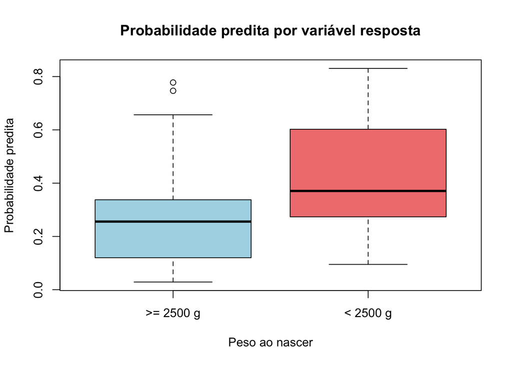

```r
# === Posterior preditiva ===
Probs <- exp(X %*% t(posterior_mat)) / (1 + exp(X %*% t(posterior_mat)))

# Amostras da resposta predita
y_rep <- matrix(
  rbinom(length(Probs), size = 1, prob = as.vector(Probs)),
  nrow = nrow(X)
)

# Probabilidade média posterior por observação
lowbwt$post_pred <- rowMeans(y_rep)

# Gráfico boxplot da probabilidade predita por grupo de peso
boxplot(post_pred ~ low, data = lowbwt,
        xlab = "Peso ao nascer",
        ylab = "Probabilidade predita",
        main = "Probabilidade predita por variável resposta",
        col = c("lightblue", "lightcoral"))
```

```r
# Classificação binária a partir da probabilidade média
lowbwt$resposta_pred <- ifelse(lowbwt$post_pred > 0.5, 1, 0)

# Tabela de confusão
tab_confusao <- table(
  Predito = lowbwt$resposta_pred,
  Observado = lowbwt$low
)
print(tab_confusao)
```

```
##        Observado
## Predito >= 2500 g < 2500 g
##       0       119       36
##       1        11       23
```